# Cian

Konstantin Ivanin

8 октября 2017 г

# Анализ данных с сайта Cian.ru по недвижимости

Логика работы следующая:

- Делаем поиск по аренде квартир с необходимыми параметрами.
- Копируем `url` в переменную.
- Смотрим сколько страниц в выдаче и записываем в другую переменную.
- Перебираем в цикле все страницы в выдаче и сохраняем необходимые поля в `tibble`.
- Делаем аналогичный поиск для продажи квартир и сохраняем результаты в другой `tibble`.
- Для каждой квартиры, выставленной на продажу, считаем её `scoring` относительно аренды.
- Сортируем по `scoring`’у и сохраняем результат для дальнейшего анализа.

Загрузим необходимые библиотеки

```r
library(data.table)
library(tidyverse)
library(rvest)
library(stringr)
library(magrittr)
library(stringr)
```

## Данные по аренде

```r
search.url <- 'https://www.cian.ru/cat.php?currency=2&deal_type=rent&engine_version=2&maxprice=999999&minprice=1&offer_type=flat&p=page&region=4593&room1=1&type=4'
pages.num <- 60 # 60 страниц в выдаче
pages <- sample(1:pages.num, pages.num)
result <- list()
count <- 1
delay <- 0

for (i in pages) {
  url.page <- str_replace(search.url, 'page', as.character(i))
  cian <- read_html(url.page)

  floor <-
    cian %>%
    html_nodes('.header--1ZTfS') %>%
    html_text() %>%
    str_trim()

  link <-
    cian %>%
    html_nodes('.cardLink--3KbME') %>%
    html_attr('href')

  area <-
    cian %>%
    html_nodes('.header--1WFWC') %>%
    html_text() %>%
    str_trim() %>%
    gsub('[^[:digit:]]', '', .) %>%
    str_trim() %>%
    as.numeric()

  address <-
    cian %>%
    html_nodes('.address-path--12tl2') %>%
    html_text() %>%
    str_trim()

  price <-
    cian %>%
    html_nodes('.header--2lxlC') %>%
    html_text() %>%
    str_trim() %>%
    gsub('[^[:digit:]]', '', .) %>%
    str_trim() %>%
    as.numeric()

  result[[i]] <- tibble(Floor = floor, Link = link, Area = area, Address = address, Price = price)
  Sys.sleep(delay)

  if (count == 1 | count %% 10 == 0 | count == pages.num)
    print(paste('Rent, page', count, 'of', length(pages)))
  count <- count + 1
}
```

```
## [1] "Rent, page 1 of 60"
## [1] "Rent, page 10 of 60"
## [1] "Rent, page 20 of 60"
## [1] "Rent, page 30 of 60"
## [1] "Rent, page 40 of 60"
## [1] "Rent, page 50 of 60"
## [1] "Rent, page 60 of 60"
```

```r
rent.data <- data.table::rbindlist(result)
```

Удалим неиспользуемые переменные

```r
rm(area, cian, address, count, delay, floor, i, link, pages, pages.num, price, search.url, url.page, result)
```

Сделаем некоторые преобразования над полученной табличкой. Разделим этажность на общую этажность дома и конкретный этаж, попробуем выделить город из полного адреса (исходим из того, что формат адреса - область, район, город), посчитаем цену за кв.метр.

```r
rent.data <- separate(rent.data, Floor, c('Floor', 'FloorAll'), ' этаж из ', convert = T)
rent.data %<>%
  mutate(PriceBySquare = Price / Area) %>%
  mutate(City = str_trim(str_split(Address, ',', simplify = T)[, 3]))
glimpse(rent.data)
```

```
## Observations: 1,680
## Variables: 8
## $ Floor         <int> 8, 1, 21, 1, 4, 5, 4, 4, 7, 2, 10, 3, 5, 11, 4, ...
## $ FloorAll      <int> 12, 9, 44, 4, 5, 5, 9, 5, 9, 5, 12, 5, 5, 15, 4,...
## $ Link          <chr> "https://zhukovsky.cian.ru/rent/flat/164955621/"...
## $ Area          <dbl> 33, 33, 36, 48, 31, 37, 22, 33, 33, 30, 30, 31, ...
## $ Address       <chr> "Московская область, Жуковский городской округ, ...
## $ Price         <dbl> 20000, 25000, 35000, 10000, 12000, 15000, 15000,...
## $ PriceBySquare <dbl> 606.0606, 757.5758, 972.2222, 208.3333, 387.0968...
## $ City          <chr> "Жуковский", "м. Новокосино", "Красногорск", "Кр...
```

Сохраним данные в `csv` формате

```r
write_csv(rent.data, 'data/cian_rent.csv')
```

## Данные по продаже

Сделаем аналогичные загрузку и преобразования для продажи квартир

```r
search.url <- 'https://www.cian.ru/cat.php?currency=2&deal_type=sale&engine_version=2&maxprice=2000000&minprice=1&offer_type=flat&p=page&region=4593&room1=1'
pages.num <- 60 # 60 страниц в выдаче
pages <- sample(1:pages.num, pages.num)
result <- list()
count <- 1
delay <- 0

for (i in pages) {
  url.page <- str_replace(search.url, 'page', as.character(i))
  cian <- read_html(url.page)

  floor <-
    cian %>%
    html_nodes('.header--1ZTfS') %>%
    html_text() %>%
    str_trim()

  link <-
    cian %>%
    html_nodes('.cardLink--3KbME') %>%
    html_attr('href')

  area <-
    cian %>%
    html_nodes('.header--1WFWC') %>%
    html_text() %>%
    str_trim() %>%
    gsub('[^[:digit:]]', '', .) %>%
    str_trim() %>%
    as.numeric()

  address <-
    cian %>%
    html_nodes('.address-path--12tl2') %>%
    html_text() %>%
    str_trim()

  price <-
    cian %>%
    html_nodes('.header--2lxlC') %>%
    html_text() %>%
    str_replace_all(',', '.') %>%
    str_trim()
  price <- ifelse(str_detect(price, '.+?(?= млн)'),
         as.numeric(str_match(price, '.+?(?= млн| тыс)')) * 1000000,
         as.numeric(str_match(price, '.+?(?= млн| тыс)')) * 1000)

  result[[i]] <- tibble(Floor = floor, Link = link, Area = area, Address = address, Price = price)
  Sys.sleep(delay)

  if (count == 1 | count %% 10 == 0 | count == pages.num)
    print(paste('Sale, page', count, 'of', length(pages)))
  count <- count + 1
}
```

```
## [1] "Sale, page 1 of 60"
## [1] "Sale, page 10 of 60"
## [1] "Sale, page 20 of 60"
## [1] "Sale, page 30 of 60"
## [1] "Sale, page 40 of 60"
## [1] "Sale, page 50 of 60"
## [1] "Sale, page 60 of 60"
```

```r
sale.data <- data.table::rbindlist(result)
```

Удалим неиспользуемые переменные

```r
rm(area, cian, address, count, delay, floor, i, link, pages, pages.num, price, search.url, url.page, result)
```

Сделаем некоторые преобразования над полученной табличкой. Разделим этажность на общую этажность дома и конкретный этаж, попробуем выделить город из полного адреса (исходим из того, что формат адреса - область, район, город), посчитаем цену за кв.метр.

```r
sale.data %<>%
  filter(str_detect(sale.data$Floor, ' этаж из '))
sale.data <- separate(sale.data, Floor, c('Floor', 'FloorAll'), ' этаж из ', convert = T)
sale.data %<>%
  mutate(PriceBySquare = Price / Area) %>%
  mutate(City = str_trim(str_split(Address, ',', simplify = T)[, 3]))
glimpse(sale.data)
```

```
## Observations: 1,679
## Variables: 8
## $ Floor         <int> 7, 1, 6, 1, 1, 3, 2, 4, 1, 2, 1, 2, 4, 2, 5, 9, ...
## $ FloorAll      <int> 15, 8, 9, 1, 1, 5, 3, 5, 5, 3, 2, 5, 6, 2, 5, 9,...
## $ Link          <chr> "https://dmitrov.cian.ru/sale/flat/152874047/", ...
## $ Area          <dbl> 37, 25, 19, 30, 32, 13, 34, 38, 21, 20, 30, 23, ...
## $ Address       <chr> "Московская область, м. Тимирязевская, Дмитровск...
## $ Price         <dbl> 1940000, 1790000, 1430000, 550000, 780000, 88000...
## $ PriceBySquare <dbl> 52432.43, 71600.00, 75263.16, 18333.33, 24375.00...
## $ City          <chr> "Дмитровский район", "Видное", "Ленинский район"...
```

Сохраним данные в `csv` формате

```r
write_csv(sale.data, 'data/cian_sale.csv')
```

## Посмотрим статистику

Посчитаем статистику по сгруппированным данным

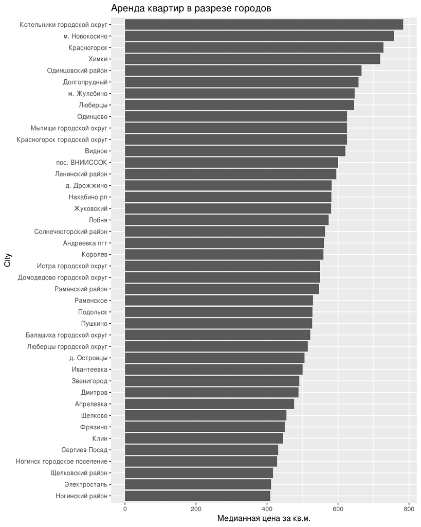

```r
rent <- rent.data %>%
  group_by(City) %>%
  summarise(
    Count = n(),
    MedianPrice = median(PriceBySquare)
  )

sale <- sale.data %>%
  group_by(City) %>%
  summarise(
    Count = n(),
    MedianPrice = median(PriceBySquare)
  )

rent %>%
  filter(Count > 5) %>%
  arrange(desc(MedianPrice)) %>%
  mutate(City = reorder(City, MedianPrice)) %>%
  ggplot(aes(City, MedianPrice)) +
  geom_bar(stat = 'identity') +
  coord_flip() +
  labs(title = 'Аренда квартир в разрезе городов',
       y = 'Медианная цена за кв.м.')
```

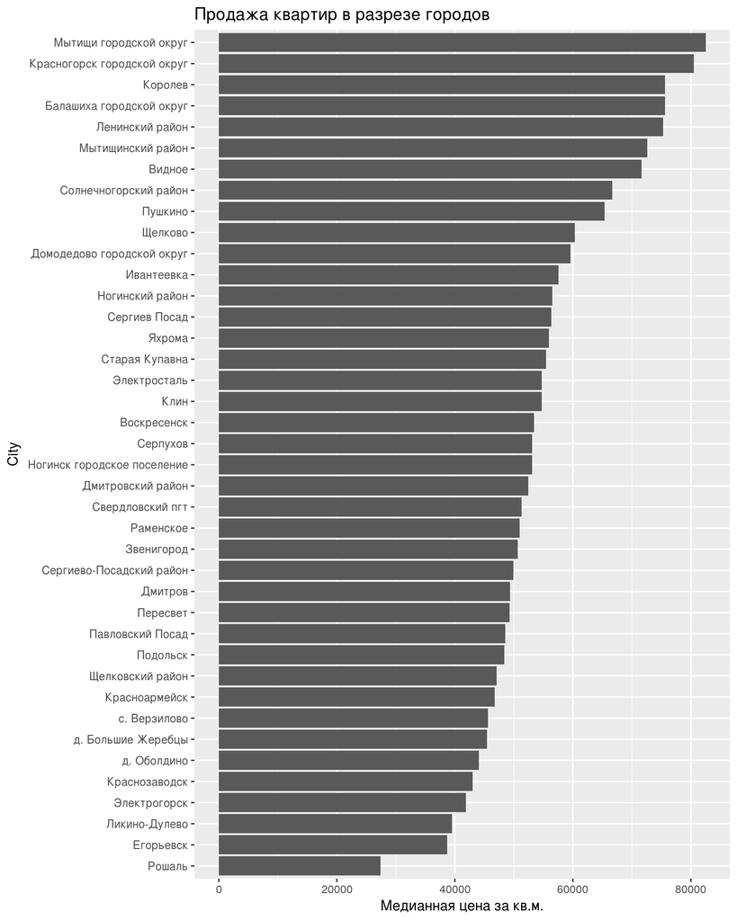

```r
sale %>%
  filter(Count > 10) %>%
  arrange(desc(MedianPrice)) %>%
  mutate(City = reorder(City, MedianPrice)) %>%
  ggplot(aes(City, MedianPrice)) +
  geom_bar(stat = 'identity') +
  coord_flip() +
  labs(title = 'Продажа квартир в разрезе городов',
       y = 'Медианная цена за кв.м.')
```

Посчитаем рейтинги

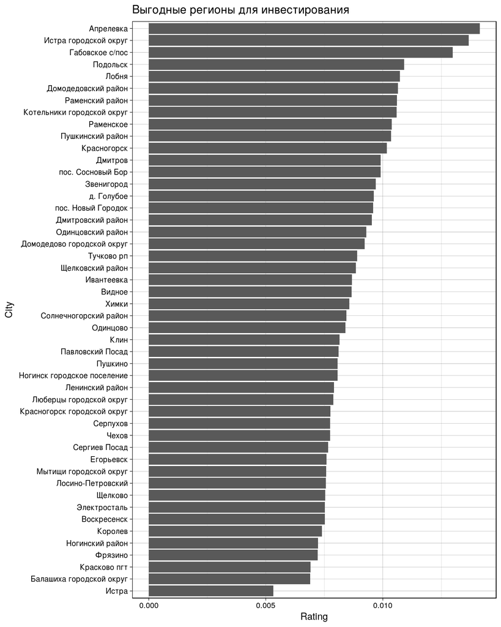

```r
result <- as.data.table(merge(sale, rent, by = 'City', suffixes = c('_sale', '_rent')))
result[, Rating := MedianPrice_rent / MedianPrice_sale]
result <- arrange(result, -Rating)
write_csv(result, 'data/cian_result.csv')
#xlsx::write.xlsx(result, 'data/result.xlsx', row.names = F)

result %>%
  filter(Count_sale > 1, Count_rent > 1) %>%
  select(City, Rating) %>%
  mutate(City = reorder(City, Rating)) %>%
  ggplot(aes(City, Rating)) +
  geom_bar(stat = 'identity') +
  coord_flip() +
  theme_linedraw() +
  labs(title = 'Выгодные регионы для инвестирования')
```

```r
setDT(sale.data)
sale.data <- merge(sale.data, select(result, City, MedianPrice_rent), by = 'City', all.x = T)
sale.data[, Rating := MedianPrice_rent / PriceBySquare]
sale.data <- arrange(sale.data, -Rating)
write_csv(sale.data, 'data/cian_sale_rating')
#xlsx::write.xlsx(sale.data, 'data/sale.data.xlsx', row.names = F)
```